# MSCA 31008 HW5

Ruoxin Shi

2022/3/5

## Cluster-wise Regression - GermanCredit

### Load Data

Load data from the library.

```r
# load data
library(caret)
data(GermanCredit)
```

Use only the numeric independent variables 1, and 3 through 7 as predictors.

```r
set.seed(1123)
# drop unnecessary variables
# selected only numerical variables as predictors

# Standardize your variables
scaled_data <- scale(GermanCredit[,c(1:7)])

# Use the 6 numeric variables other than "amount" as independent variables.
cleaned_df <- scaled_data[,c(1, 3:7)]
Amount <- scaled_data[,2]

# final data
final_data <- as.data.frame(cbind(Amount, cleaned_df))

# split
train_ind <- sample(seq_len(nrow(final_data)), size = 632)
train <- final_data[train_ind, ]
test <- final_data[-train_ind, ]
```

### Import Function

```r
# import the function
source("clustreg.txt")
source("clustreg.predict.txt")
```

### Create Model

Perform cluster-wise regression for 1, 2, and 3 clusters.

```r
clustreg_credit_1 <- clustreg(train,1,1,1123,1)
clustreg_credit_2 <- clustreg(train,2,2,1123,10)
clustreg_credit_3 <- clustreg(train,3,2,1123,10)
training_r2 <- c(clustreg_credit_1$rsq.best,clustreg_credit_2$rsq.best,clustreg_credit_3$rsq.best)
```

### Holdout Validation

Using the 3 models built with 1, 2, and 3 clusters respectively, predict classes for the holdout set.

```r
pred1 <- clustreg.predict(clustreg_credit_1, test)
pred2 <- clustreg.predict(clustreg_credit_2, test)
pred3 <- clustreg.predict(clustreg_credit_3, test)
holdout_r2 <- c(pred1$rsq, pred2$rsq, pred3$rsq)
```

Show a table of training R^2, holdout R^2, and percentage decrease from train to holdout R squared: (Train R square – Holdout R square)/ Train R square.

```r
pct_decrease <- (training_r2 - holdout_r2)/training_r2
result <- data.frame(training_r2, holdout_r2, pct_decrease)
result
```

```
##   training_r2 holdout_r2 pct_decrease
## 1   0.5390054  0.4410261   0.18177807
## 2   0.8432129  0.7623599   0.09588680
## 3   0.8911827  0.8254142   0.07379905
```

Plot the R^2 for different number of clusters.

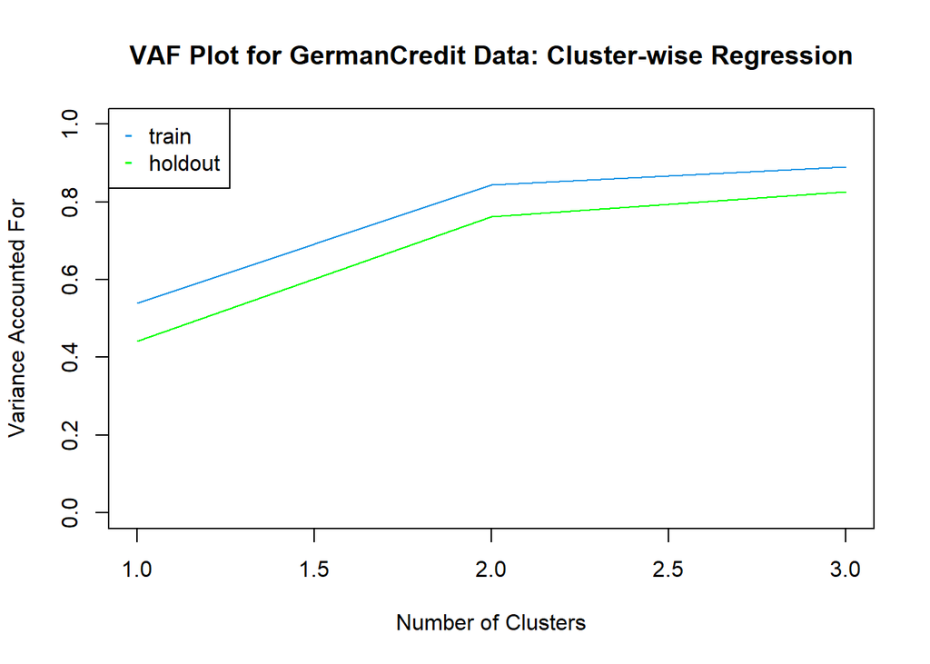

```r
plot(c(1,2,3), training_r2,
     ylim=c(0,1),type="l",col=4,main="VAF Plot for GermanCredit Data: Cluster-wise Regression",
     ylab="Variance Accounted For",xlab="Number of Clusters")
lines(c(1,2,3), holdout_r2, col="green")
legend("topleft", pch="-", col=c(4, "green"), c("train", "holdout"), cex=1)
```

**Which model is the most stable? Which performs the best on the holdout set. Which one would you choose as the final model?**

According to the percent decrease from train to holdout R^2, the most stable model is the one with 3 cluster. Also, this is the one that performs best on the holdout set. So I would choose this as the final model.

### Clustering Result

```r
cluster2 <- clustreg_credit_2$cluster
cluster3 <- clustreg_credit_3$cluster
table(cluster2, cluster3)
```

```
##         cluster3
## cluster2   1   2   3
##        1 329 108  30
##        2  14  49 102
```

```r
prop.table(table(cluster2, cluster3))
```

```
##         cluster3
## cluster2          1          2          3
##        1 0.52056962 0.17088608 0.04746835
##        2 0.02215190 0.07753165 0.16139241
```

From the above result, we could see that there are some overlap in the first cluster but little overlap in the second cluster. But we could not simply say that the second and third clusters in the 3-cluster model are splitted by the second cluster in the 2-cluster model. They are still different clusters.

```r
clustreg_credit_2$results
```

```
## [[1]]
##
## Call:
## lm(formula = dat[c.best == i, ])
##
## Residuals:
##      Min       1Q   Median       3Q      Max
## -1.12658 -0.17765 -0.00153  0.18486  0.97998
##
## Coefficients:
##                            Estimate Std. Error t value Pr(>|t|)
## (Intercept)               -0.289612   0.014789 -19.583  < 2e-16 ***
## Duration                   0.497485   0.014691  33.862  < 2e-16 ***
## InstallmentRatePercentage -0.199950   0.015511 -12.891  < 2e-16 ***
## ResidenceDuration          0.007693   0.014751   0.522  0.60226
## Age                        0.040926   0.015262   2.682  0.00759 **
## NumberExistingCredits     -0.017658   0.016471  -1.072  0.28425
## NumberPeopleMaintenance    0.017535   0.015616   1.123  0.26208
## ---
## Signif. codes:  0 '***' 0.001 '**' 0.01 '*' 0.05 '.' 0.1 ' ' 1
##
## Residual standard error: 0.316 on 460 degrees of freedom
## Multiple R-squared:  0.731,  Adjusted R-squared:  0.7275
## F-statistic: 208.4 on 6 and 460 DF,  p-value: < 2.2e-16
##
##
## [[2]]
## [[2]][[1]]
##
## Call:
## lm(formula = dat[c.best == i, ])
##
## Residuals:
##     Min      1Q  Median      3Q     Max
## -1.0092 -0.2583 -0.1025  0.2036  2.7189
##
## Coefficients:
##                           Estimate Std. Error t value Pr(>|t|)
## (Intercept)                0.80795    0.04254  18.992  < 2e-16 ***
## Duration                   0.97279    0.04020  24.200  < 2e-16 ***
## InstallmentRatePercentage -0.27548    0.04260  -6.466 1.19e-09 ***
## ResidenceDuration          0.04923    0.04539   1.085 0.279788
## Age                        0.17937    0.05158   3.477 0.000654 ***
## NumberExistingCredits     -0.09798    0.04110  -2.384 0.018309 *
## NumberPeopleMaintenance   -0.04270    0.04138  -1.032 0.303706
## ---
## Signif. codes:  0 '***' 0.001 '**' 0.01 '*' 0.05 '.' 0.1 ' ' 1
##
## Residual standard error: 0.5345 on 158 degrees of freedom
## Multiple R-squared:  0.8234, Adjusted R-squared:  0.8167
## F-statistic: 122.8 on 6 and 158 DF,  p-value: < 2.2e-16
##
##
## [[2]][[2]]
## [[2]][[2]][[1]]
## [1] "Complete"
```

```r
clustreg_credit_3$results
```

```
## [[1]]
##
## Call:
## lm(formula = dat[c.best == i, ])
##
## Residuals:
##     Min      1Q  Median      3Q     Max
## -0.7823 -0.1472 -0.0064  0.1408  0.9800
##
## Coefficients:
##                           Estimate Std. Error t value Pr(>|t|)
## (Intercept)               -0.36977    0.01342 -27.549  < 2e-16 ***
## Duration                   0.38500    0.01431  26.909  < 2e-16 ***
## InstallmentRatePercentage -0.19052    0.01385 -13.759  < 2e-16 ***
## ResidenceDuration          0.05105    0.01347   3.789 0.000179 ***
## Age                       -0.02331    0.01406  -1.658 0.098308 .
## NumberExistingCredits      0.03214    0.01483   2.167 0.030971 *
## NumberPeopleMaintenance    0.00957    0.01486   0.644 0.519919
## ---
## Signif. codes:  0 '***' 0.001 '**' 0.01 '*' 0.05 '.' 0.1 ' ' 1
##
## Residual standard error: 0.2424 on 336 degrees of freedom
## Multiple R-squared:  0.7122, Adjusted R-squared:  0.7071
## F-statistic: 138.6 on 6 and 336 DF,  p-value: < 2.2e-16
##
##
## [[2]]
## [[2]][[1]]
##
## Call:
## lm(formula = dat[c.best == i, ])
##
## Residuals:
##      Min       1Q   Median       3Q      Max
## -0.77491 -0.16949 -0.02811  0.12395  2.17451
##
## Coefficients:
##                           Estimate Std. Error t value Pr(>|t|)
## (Intercept)                0.17712    0.02905   6.096 8.78e-09 ***
## Duration                   0.66816    0.02413  27.686  < 2e-16 ***
```

[output cut: 28 more lines]

```
## ResidenceDuration          0.21142    0.04251   4.974 2.12e-06 ***
## Age                       -0.13005    0.04039  -3.220  0.00163 **
## NumberExistingCredits     -0.07751    0.03670  -2.112  0.03667 *
## NumberPeopleMaintenance   -0.01888    0.03921  -0.481  0.63108
## ---
## Signif. codes:  0 '***' 0.001 '**' 0.01 '*' 0.05 '.' 0.1 ' ' 1
##
## Residual standard error: 0.4504 on 125 degrees of freedom
## Multiple R-squared:  0.8852, Adjusted R-squared:  0.8797
## F-statistic: 160.7 on 6 and 125 DF,  p-value: < 2.2e-16
##
##
## [[2]][[2]][[2]]
## [[2]][[2]][[2]][[1]]
## [1] "Complete"
```